# 텍스트마이닝

## 정규 표현식 (Regular Expression)

- 정규 표현식은 텍스트 문자열을 패턴으로 파악하여 식별하는데 쓰인다. 즉, 문자열이 주어진 규칙에 일치하는지, 일치하지 않는지 판단할 수 있다.

Example) 신문기사 본문을 수집할 경우 본문에 기자의 이메일 주소가 들어가 있는 경우가 많다. 실제 텍스트 자료를 분석 시 이러한 내용은 불필요하므로 제거해야 하는데 이때 정규 표현식을 활용해 이메일 주소 패턴에 일치하는 문자열을 찾아 삭제할 수 있다.  
예제 신문기사 본문 링크: https://news.naver.com/main/read.nhn?mode=LSD&mid=sec&sid1=103&oid=032&aid=0003071204

```python
import re # 정규식 사용을 위한 패키지
```

```python
string = '배우 윤여정씨가 영화 <미나리>로 아카데미 여우조연상을 수상했다. 한국 배우가 아카데미에서 상을 받은 건 처음이다. 윤여정씨가 25일(현지시간) 미국 로스앤젤레스 유니언 스테이션에서 열린 제93회 아카데미 시상식에서 여우조연상을 받았다. 윤씨는 영화 <힐빌리의 노래>의 글렌 클로스, <보랏 서브시퀀트 무비필름>의 마리아 바칼로바, <맹크>의 어맨다 사이프리드, <더 파더>의 올리비아 콜먼 등을 제치고 수상했다. 그는 수상 소감에서 “나는 경쟁을 믿지 않는다. 어떻게 내가 (함께 여우조연상 후보에 오른) 글렌 클로스를 이길 수 있겠냐”며 “다른 배우들보다 조금 더 운이 좋았을 뿐이다. 한국 배우에 대한 미국인들의 환대라고 생각한다”고 말했다. 윤씨는 아울러 자신의 데뷔작 <화녀>(1971)를 연출한 고 김기영 감독을 언급하며 “살아 계셨다면 수상을 기뻐해 주셨을 것”이라고 말했다. 그는 시상식 직후 한국 기자들과 만나 “아카데미가 전부가 아니고, 지금이 최고의 순간인지도 모르겠다”며 “남한테 민폐를 끼치지 않을 때까지 이 일을 하다가 죽으면 참 좋을 것 같다”고 말했다. <미나리>는 1980년대 미국 남부 아칸소에 이주한 한인 가정의 이야기를 그린 영화다. 윤씨는 이 영화에서 딸(한예리)을 돕기 위해 미국 땅을 밟은 한국 할머니 역을 맡았다. 이날 여우조연상 시상은 <미나리>의 제작사 플랜B 설립자인 배우 브래드 피트가 맡았다. 지난해 <기생충>이 작품상 등 아카데미 4개 부문에서 수상했지만, 배우들은 수상자 후보에 오르지 않았다. 윤씨는 이번 수상으로 <사요나라>(1957)의 우메키 미요시 이후 두번째로 아카데미 여우조연상을 받은 아시아 배우로도 기록됐다. 그는 <미나리>로 미국 배우조합상, 영국 아카데미 시상식 등에서 각종 상을 받으며 아카데미 수상 기대감을 높여왔다. 백승찬 기자 myungworry@kyunghyang.com'
print(string)
```

```
배우 윤여정씨가 영화 <미나리>로 아카데미 여우조연상을 수상했다. 한국 배우가 아카데미에서 상을 받은 건 처음이다. 윤여정씨가 25일(현지시간) 미국 로스앤젤레스 유니언 스테이션에서 열린 제93회 아카데미 시상식에서 여우조연상을 받았다. 윤씨는 영화 <힐빌리의 노래>의 글렌 클로스, <보랏 서브시퀀트 무비필름>의 마리아 바칼로바, <맹크>의 어맨다 사이프리드, <더 파더>의 올리비아 콜먼 등을 제치고 수상했다. 그는 수상 소감에서 “나는 경쟁을 믿지 않는다. 어떻게 내가 (함께 여우조연상 후보에 오른) 글렌 클로스를 이길 수 있겠냐…
```

```python
re.sub('[A-Za-z0-9\._+]+@[A-Za-z]+\.(com|org|edu|net|co.kr)', ' ', string)
```

```
'배우 윤여정씨가 영화 <미나리>로 아카데미 여우조연상을 수상했다. 한국 배우가 아카데미에서 상을 받은 건 처음이다. 윤여정씨가 25일(현지시간) 미국 로스앤젤레스 유니언 스테이션에서 열린 제93회 아카데미 시상식에서 여우조연상을 받았다. 윤씨는 영화 <힐빌리의 노래>의 글렌 클로스, <보랏 서브시퀀트 무비필름>의 마리아 바칼로바, <맹크>의 어맨다 사이프리드, <더 파더>의 올리비아 콜먼 등을 제치고 수상했다. 그는 수상 소감에서 “나는 경쟁을 믿지 않는다. 어떻게 내가 (함께 여우조연상 후보에 오른) 글렌 클로스를 이길 수 있겠…
```

## 전처리 (Text preprocessing)

- 텍스트 마이닝에 적용되는 텍스트 데이터 집합을 '말뭉치(corpus)'라고 부른다. 이는 대용량의 정형화된 텍스트 집단으로 정의되는데, '정형화된'이란 뜻은 원(raw) 텍스트 데이터가 사전 처리 작업이 되었음을 의미한다.
- 텍스트 데이터의 전처리 과정은 특정한 법칙이나 규정은 없지만, 일반적으로 몇 가지 공통적인 과정을 거친다.

### (1) 대소문자 통일

- 한글 텍스트에 해당되지는 않지만, 영어의 경우 대소문자를 구분해 사용한다. (문장의 첫 단어, 고유명사, 축약어, 강조어 등) 파이썬의 경우 같은 철자라도 대문자와 소문자를 서로 다른 문자로 인식하기 때문에 한 방식으로 일치시켜야한다.

```python
s = 'Hello World'
```

```python
s.lower()
```

```
'hello world'
```

```python
s.upper()
```

```
'HELLO WORLD'
```

### (2) 숫자, 문장부호, 특수문자 제거

- 원 데이터에는 텍스트 뿐만 아니라 숫자, 문장부호, 특수문자 등이 모두 포함되어 있다. 이 것들은 대부분 분석에 포함되지 않기 때문에 제거하는 과정이 필요하다. (단, 경우에 따라 필요한 숫자, 문장부호, 특수문자 등이 존재하기 때문에 연구자의 판단에 따라 제거 대상을 선별하는 경우도 있다.)

```python
r_number = re.compile('[0-9]+') # 숫자 제거
r_symbol = re.compile('\W+') # 특수문자 제거
r_underbar = re.compile('_') # 추가적으로 제거해야 하는 기호가 있을 경우
```

```python
string = '문재인정부의 전체 887개 공약 중 완료된 것은 155건으로 17.47%의 이행률을 기록 중인 것으로 나타났다.'
print(string)
```

```
문재인정부의 전체 887개 공약 중 완료된 것은 155건으로 17.47%의 이행률을 기록 중인 것으로 나타났다.
```

```python
string = r_number.sub(' ', string)
print(string)
```

```
문재인정부의 전체  개 공약 중 완료된 것은  건으로  . %의 이행률을 기록 중인 것으로 나타났다.
```

```python
string = r_symbol.sub(' ', string)
print(string)
```

```
문재인정부의 전체 개 공약 중 완료된 것은 건으로 의 이행률을 기록 중인 것으로 나타났다
```

```python
string = 'TM_Text_Data'
print(string)
```

```
TM_Text_Data
```

```python
r_underbar.sub(' ', string)
```

```
'TM Text Data'
```

### (3) 불용어 (stopword) 제거

- 텍스트 데이터에 자주 사용되지만 특별한 의미를 부여하기 힘든 단어를 '불용어(stopword)'라고 부른다. (예를들면 영어의 'the', 'a', 'an'과 같은 관사)
- 파이썬에서 가장 많이 쓰는 불용어 리스트 패키지는 'NLTK'인데 아쉽게도 한국어의 경우 아직 지원하지 않는다. 따라서 한국어의 경우는 불용어 리스트를 직접 작성해 사용하게 된다.

```python
from nltk.corpus import stopwords
```

```python
# 한국어 불용어 제거 방법
words_korean = ['추석', '연휴', '민족', '대이동', '시작', '늘어', '교통량', '교통사고',
                '특히', '자동차', '고장', '상당수', '차지', '나타', '것', '기자']
print(words_korean)
```

```
['추석', '연휴', '민족', '대이동', '시작', '늘어', '교통량', '교통사고', '특히', '자동차', '고장', '상당수', '차지', '나타', '것', '기자']
```

```python
# 불용어 리스트 생성
stopwords_korean = ['늘어', '특히', '나타', '것', '기자']

# 불용어 리스트를 활용해 제거
words_korean = [i for i in words_korean if i not in stopwords_korean]
print(words_korean)
```

```
['추석', '연휴', '민족', '대이동', '시작', '교통량', '교통사고', '자동차', '고장', '상당수', '차지']
```

```python
# 영어 불용어 제거 방법

words_english = ['chief', 'justice', 'roberts', 'president', 'carter', 'clinton', 'bush', 'obama', 'fellow', 'americans',
                'and', 'people', 'of', 'the', 'world', 'thank', 'you']
print(words_english)
```

```
['chief', 'justice', 'roberts', 'president', 'carter', 'clinton', 'bush', 'obama', 'fellow', 'americans', 'and', 'people', 'of', 'the', 'world', 'thank', 'you']
```

```python
StopWords = set(stopwords.words('english'))
```

```python
words_english = [w for w in words_english if not w in StopWords]
print(words_english)
```

```
['chief', 'justice', 'roberts', 'president', 'carter', 'clinton', 'bush', 'obama', 'fellow', 'americans', 'people', 'world', 'thank']
```

## 품사 분석 (Part Of Speech, POS)

- 문장을 구성하는 개별 단어는 문장 안에서 고유한 문법적 기능을 수행한다.
- 동일한 단어라도 서로 다른 품사로 쓰이는 경우가 있다. 보통의 경우 같은 단어를 품사와 관계없이 동일한 형태의 단어로 보고 분석하는 경우가 있지만, 경우에 따라 특정 품사만을 수집해 분석하고 싶은 경우도 있다. (예를들어 문서의 감정 정도를 파악하고 싶은 경우 형용사만 추출하면 더욱 효율적으로 파악할 수 있다.) 기본적인 텍스트 마이닝은 문서에서 명사만을 추출해서 분석하는 경우가 대부분이다.
- 한국어 품사 분석을 위해 KoNLPy 패키지를 사용한다. 이 패키지 안에서 Kkma, Komoran, Hannaum, Twitter, Mecab 클래스를 이용해 품사 분석을 할 수 있다. 실행 시간과 정확도에 대한 판단 기준을 통해 클래스를 선택하면 된다.
- 영어의 경우 NLTK 패키지를 사용하면 된다.

```python
from IPython.display import Image
```

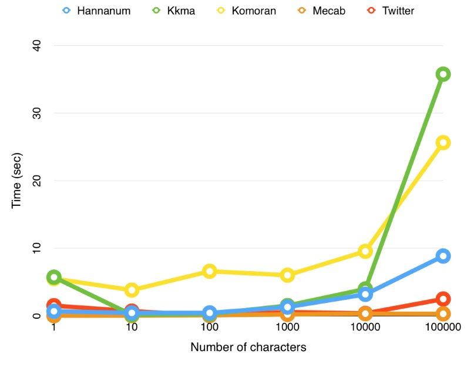

```python
Image("C:/Users/Asan/Desktop/data_science/textmining/pos_class.jpg")
```

```python
# 한국어 품사분석
from konlpy.tag import Hannanum
from konlpy.tag import Kkma
from konlpy.tag import Twitter
from konlpy.tag import Okt # KoNLPy v0.4.5. 이후에는 "Twitter" 클래스 명이 "Okt"로 변경

string_kor = "친척들이 모인 이번 추석 차례상에서는 단연 '집값'이 화제에 올랐다."
```

- morphs : 문장을 형태소 단위로 끊어주는 매서드
- nouns : 명사를 추출해주는 매서드
- pos : 각 형태소의 품사까지 알려주는 매서드

```python
# Hannanum
hannanum = Hannanum()
morphs_hannanum = hannanum.morphs(string_kor)
nouns_hannanum = hannanum.nouns(string_kor)
pos_hannanum = hannanum.pos(string_kor)
print(morphs_hannanum)
print(nouns_hannanum)
print(pos_hannanum)
```

```
['친척들', '이', '모이', 'ㄴ', '이번', '추석', '차례상', '에서는', '단연', "'", '집값', "'", '이', '화제', '에', '오르', '아다', '.']
['친척들', '이번', '추석', '차례상', '집값', '화제']
[('친척들', 'N'), ('이', 'J'), ('모이', 'P'), ('ㄴ', 'E'), ('이번', 'N'), ('추석', 'N'), ('차례상', 'N'), ('에서는', 'J'), ('단연', 'M'), ("'", 'S'), ('집값', 'N'), ("'", 'S'), ('이', 'J'), ('화제', 'N'), ('에', 'J'), ('오르', 'P'), ('아다', 'E'), ('.', 'S')]
```

```python
# Kkma
kkma = Kkma()
morphs_kkma = kkma.morphs(string_kor)
nouns_kkma = kkma.nouns(string_kor)
pos_kkma = kkma.pos(string_kor)
print(morphs_kkma)
print(nouns_kkma)
print(pos_kkma)
```

```
['친척', '들', '이', '모이', 'ㄴ', '이번', '추석', '차례', '상', '에서', '는', '단연', "'", '집', '값', "'", '이', '화제', '에', '오르', '았', '다', '.']
['친척', '이번', '추석', '차례', '차례상', '상', '집', '집값', '값', '화제']
[('친척', 'NNG'), ('들', 'XSN'), ('이', 'JKS'), ('모이', 'VV'), ('ㄴ', 'ETD'), ('이번', 'NNG'), ('추석', 'NNG'), ('차례', 'NNG'), ('상', 'NNG'), ('에서', 'JKM'), ('는', 'JX'), ('단연', 'MAG'), ("'", 'SS'), ('집', 'NNG'), ('값', 'NNG'), ("'", 'SS'), ('이', 'MDT'), ('화제', 'NNG'), ('에', 'JKM'), ('오르', 'VV'), ('았', 'EPT'), (…
```

```python
# Twitter, KoNLPy v0.4.5. 이후에는 "Twitter" 클래스 명이 "Okt"로 변경
twitter = Twitter()
morphs_twitter = twitter.morphs(string_kor)
nouns_twitter = twitter.nouns(string_kor)
pos_twitter = twitter.pos(string_kor)
print(morphs_twitter)
print(nouns_twitter)
print(pos_twitter)
```

```
['친척', '들', '이', '모인', '이번', '추석', '차례상', '에서는', '단연', "'", '집값', "'", '이', '화제', '에', '올랐다', '.']
['친척', '이번', '추석', '차례상', '단연', '집값', '이', '화제']
[('친척', 'Noun'), ('들', 'Suffix'), ('이', 'Josa'), ('모인', 'Verb'), ('이번', 'Noun'), ('추석', 'Noun'), ('차례상', 'Noun'), ('에서는', 'Josa'), ('단연', 'Noun'), ("'", 'Punctuation'), ('집값', 'Noun'), ("'", 'Punctuation'), ('이', 'Noun'), ('화제', 'Noun'), ('에', 'Josa'), ('올랐다', 'Verb'), ('.', 'Punctuation')]
```

```python
# Okt
okt = Okt()
morphs_okt = okt.morphs(string_kor)
nouns_okt = okt.nouns(string_kor)
pos_okt = okt.pos(string_kor)
print(morphs_okt)
print(nouns_okt)
print(pos_okt)
```

```
['친척', '들', '이', '모인', '이번', '추석', '차례상', '에서는', '단연', "'", '집값', "'", '이', '화제', '에', '올랐다', '.']
['친척', '이번', '추석', '차례상', '단연', '집값', '이', '화제']
[('친척', 'Noun'), ('들', 'Suffix'), ('이', 'Josa'), ('모인', 'Verb'), ('이번', 'Noun'), ('추석', 'Noun'), ('차례상', 'Noun'), ('에서는', 'Josa'), ('단연', 'Noun'), ("'", 'Punctuation'), ('집값', 'Noun'), ("'", 'Punctuation'), ('이', 'Noun'), ('화제', 'Noun'), ('에', 'Josa'), ('올랐다', 'Verb'), ('.', 'Punctuation')]
```

```python
# 영어 품사분석
from nltk import pos_tag

string_eng = 'The little yellow dog barked at the Persian cat'.split()
pos_nltk = pos_tag(string_eng)
print(pos_nltk)
```

```
[('The', 'DT'), ('little', 'JJ'), ('yellow', 'JJ'), ('dog', 'NN'), ('barked', 'VBD'), ('at', 'IN'), ('the', 'DT'), ('Persian', 'JJ'), ('cat', 'NN')]
```

## 단어 빈도분석 (Word Frequency)

- 텍스트 데이터에 대한 빈도분석은 가장 기본적이지만 쉽고 보편적으로 활용되는 방법이며, 본격적인 분석 이전에 데이터에 대한 이해와 흐름을 살펴보기 위한 기초 분석에 해당한다. (기존 수치 데이터 분석 이전 평균, 표준편차 등을 구하는 것과 유사하다.)

```python
# 한글 단어 빈도분석
import pandas as pd
from konlpy.tag import Hannanum
from konlpy.tag import Kkma
hannanum = Hannanum()
kkma = Kkma()
```

```python
f_kor = open('C:/Users/Asan/Desktop/data_science/textmining/moon.txt', 'r')
lines_kor = f_kor.readlines()
f_kor.close()
print(lines_kor)
```

```
['존경하고 사랑하는 국민 여러분. 감사합니다. 국민 여러분의 위대한 선택에 머리 숙여 깊이 감사드립니다. 저는 오늘 대한민국 제 19대 대통령으로서 새로운 대한민국을 향해 첫걸음을 내딛습니다. 지금 제 두 어깨는 국민 여러분으로부터 부여받은 막중한 소명감으로 무겁습니다. 지금 제 가슴은 한번도 경험하지 못한 나라를 만들겠다는 열정으로 뜨겁습니다. 그리고 지금 제 머리는 통합과 공존의 새로운 세상을 열어갈 청사진으로 가득 차 있습니다.\n', '우리가 만들어가려는 새로운 대한민국은 숱한 좌절과 패배에도 불구하고 우리의 선대들이 일관…
```

```python
temp_hannanum = []
temp_kkma = []

for i in range(len(lines_kor)):
    temp_hannanum.append(hannanum.nouns(lines_kor[i]))
    temp_kkma.append(kkma.nouns(lines_kor[i]))
```

```python
print(temp_hannanum)
```

```
[['존경', '사랑', '국민', '여러분', '감사', '국민', '여러분', '위대한', '선택', '머리', '저', '오늘', '대한민국', '저', '19대', '대통령', '대한민국', '첫걸음', '저', '두', '어깨', '국민', '여러분', '부', '막중', '소명감', '저', '가슴', '한번', '경험', '나라', '열정', '저', '머리', '통합', '공존', '세상', '청사진'], ['우리', '대한민국', '좌절', '패배', '불구', '우리', '선대들', '일관', '추구', '나라',…
```

```python
print(temp_kkma)
```

```
[['존경', '사랑', '국민', '분', '감사', '여러분', '선택', '머리', '저', '오늘', '대한', '대한민국', '민국', '제', '19', '19대', '대', '대통령', '첫걸음', '어깨', '소명감', '가슴', '한번', '경험', '나라', '열정', '통합', '공존', '세상', '청사진'], ['우리', '새', '대한', '대한민국', '민국', '숱', '좌절', '패배', '선대', '일관', '추구', '나라', '희생', '헌신', '감내', '젊은이', '저', '역사', '국민'…
```

```python
# 각 line들을 합쳐주는 함수 작성
def flatten(l):
    flatList = []
    for elem in l:
        if type(elem) == list:
            for e in elem:
                flatList.append(e)
        else:
            flatList.append(elem)
    return flatList
```

```python
word_list_hannanum = flatten(temp_hannanum)
print(word_list_hannanum)
```

```
['존경', '사랑', '국민', '여러분', '감사', '국민', '여러분', '위대한', '선택', '머리', '저', '오늘', '대한민국', '저', '19대', '대통령', '대한민국', '첫걸음', '저', '두', '어깨', '국민', '여러분', '부', '막중', '소명감', '저', '가슴', '한번', '경험', '나라', '열정', '저', '머리', '통합', '공존', '세상', '청사진', '우리', '대한민국', '좌절', '패배', '불구', '우리', '선대들', '일관', '추구', '나라', '희…
```

```python
word_list_kkma = flatten(temp_kkma)
print(word_list_kkma)
```

```
['존경', '사랑', '국민', '분', '감사', '여러분', '선택', '머리', '저', '오늘', '대한', '대한민국', '민국', '제', '19', '19대', '대', '대통령', '첫걸음', '어깨', '소명감', '가슴', '한번', '경험', '나라', '열정', '통합', '공존', '세상', '청사진', '우리', '새', '대한', '대한민국', '민국', '숱', '좌절', '패배', '선대', '일관', '추구', '나라', '희생', '헌신', '감내', '젊은이', '저', '역사', '국민', '…
```

```python
word_list_hannanum = pd.Series([x for x in word_list_hannanum if len(x)>1])
pd.DataFrame(word_list_hannanum)
```

|  | 0 |
| --- | --- |
| 0 | 존경 |
| 1 | 사랑 |
| 2 | 국민 |
| 3 | 여러분 |
| 4 | 감사 |
| ... | ... |
| 387 | 국민들 |
| 388 | 따뜻한 |
| 389 | 대통령 |
| 390 | 친구 |
| 391 | 대통령 |

392 rows × 1 columns

```python
word_list_kkma = pd.Series([x for x in word_list_kkma if len(x)>1])
pd.DataFrame(word_list_kkma)
```

|  | 0 |
| --- | --- |
| 0 | 존경 |
| 1 | 사랑 |
| 2 | 국민 |
| 3 | 감사 |
| 4 | 여러분 |
| ... | ... |
| 364 | 광화 |
| 365 | 광화문 |
| 366 | 시대 |
| 367 | 국민 |
| 368 | 친구 |

369 rows × 1 columns

```python
word_list_hannanum_20 = word_list_hannanum.value_counts().head(20)
pd.DataFrame(word_list_hannanum_20)
```

|  | 0 |
| --- | --- |
| 대통령 | 29 |
| 국민 | 19 |
| 대한민국 | 9 |
| 우리 | 8 |
| 여러분 | 7 |
| 역사 | 6 |
| 국민들 | 6 |
| 나라 | 6 |
| 대통령의 | 5 |
| 세상 | 5 |
| 선거 | 4 |
| 대화 | 4 |
| 해결 | 4 |
| 존경 | 4 |
| 정치 | 4 |
| 오늘 | 4 |
| 이번 | 4 |
| 머리 | 3 |
| 소통 | 3 |
| 광화문 | 3 |

```python
word_list_kkma_20 = word_list_kkma.value_counts().head(20)
pd.DataFrame(word_list_kkma_20)
```

|  | 0 |
| --- | --- |
| 대통령 | 13 |
| 국민 | 12 |
| 선거 | 5 |
| 대한민국 | 5 |
| 대한 | 5 |
| 민국 | 5 |
| 우리 | 5 |
| 나라 | 5 |
| 세상 | 4 |
| 존경 | 4 |
| 오늘 | 4 |
| 역사 | 4 |
| 지지 | 4 |
| 정치 | 4 |
| 약속 | 3 |
| 대화 | 3 |
| 이번 | 3 |
| 여러분 | 3 |
| 과정 | 3 |
| 선택 | 2 |

```python
# 막대 그래프 (bar-chart)
from matplotlib import pyplot as plt
from matplotlib import rcParams, style
style.use('ggplot')

from matplotlib import font_manager, rc
font_name = font_manager.FontProperties(fname = "C:/Windows/Fonts/malgun.ttf").get_name()
rc('font', family = font_name)
plt.rcParams['figure.figsize'] = (15, 10)
```

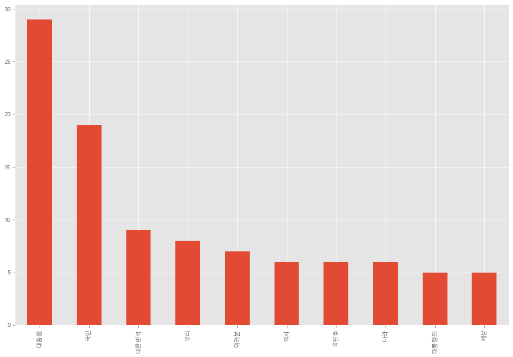

```python
word_list_hannanum_20[0:10].plot.bar()
```

```python
# 영어 단어 빈도분석
import pandas as pd
import nltk
from nltk.stem.porter import PorterStemmer
from nltk.tokenize import RegexpTokenizer
from nltk.corpus import stopwords
```

```python
f_eng = open('C:/Users/Asan/Desktop/data_science/textmining/trump.txt', 'r')
lines_eng = f_eng.readlines()[0]
f_eng.close()
print(lines_eng)
```

```
Chief Justice Roberts, President Carter, President Clinton, President Bush, President Obama, fellow Americans and people of the world, thank you. We, the citizens of America are now joined in a great national effort to rebuild our country and restore its promise for all of our people. Together, we w…
```

```python
tokenizer = RegexpTokenizer('[\w]+')
stop_words = stopwords.words('english')
```

```python
words = lines_eng.lower() # 소문자화
tokens = tokenizer.tokenize(words)
stopped_tokens = [i for i in list((tokens)) if not i in stop_words] # 불용어 제거
stopped_tokens2 = [i for i in stopped_tokens if len(i)>1] # 단어길이 1 이하 제거
print(stopped_tokens2)
```

```
['chief', 'justice', 'roberts', 'president', 'carter', 'president', 'clinton', 'president', 'bush', 'president', 'obama', 'fellow', 'americans', 'people', 'world', 'thank', 'citizens', 'america', 'joined', 'great', 'national', 'effort', 'rebuild', 'country', 'restore', 'promise', 'people', 'together…
```

```python
word_list_eng_20 = pd.Series(stopped_tokens2).value_counts().head(20)
pd.DataFrame(word_list_eng_20)
```

|  | 0 |
| --- | --- |
| america | 20 |
| american | 11 |
| people | 10 |
| country | 9 |
| one | 8 |
| nation | 7 |
| every | 7 |
| world | 6 |
| back | 6 |
| great | 6 |
| new | 6 |
| never | 6 |
| protected | 5 |
| right | 5 |
| president | 5 |
| god | 5 |
| make | 5 |
| many | 5 |
| across | 5 |
| dreams | 5 |

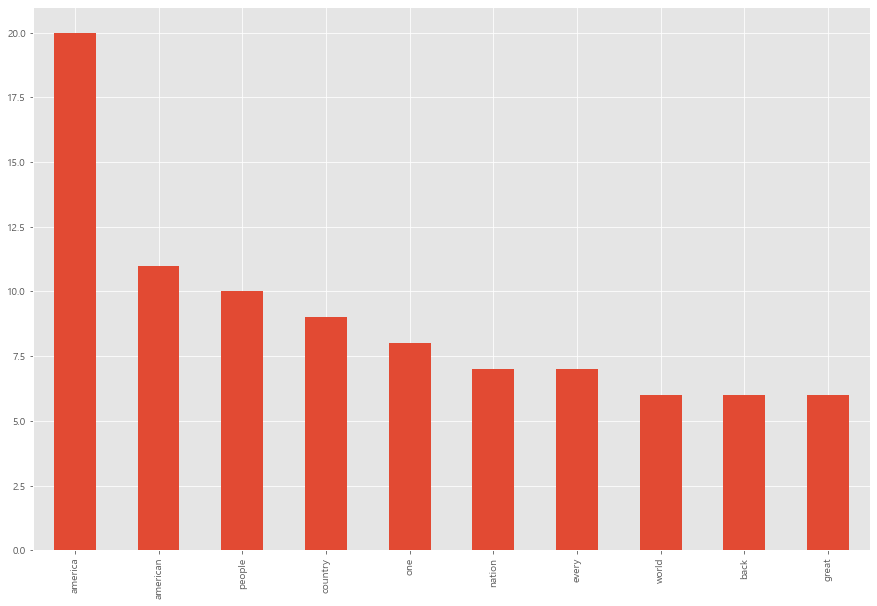

```python
word_list_eng_20[0:10].plot.bar()
```

## 워드크라우드 (Word Cloud)

```python
from wordcloud import WordCloud
from collections import Counter
import matplotlib.pyplot as plt
font_path = "c:/windows/fonts/malgun.ttf"
wordcloud = WordCloud(font_path = font_path, width = 800, height = 800, background_color = 'white')
```

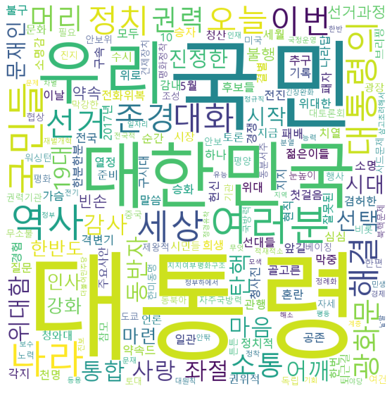

```python
# 한글 워드크라우드
count_kor = Counter(word_list_hannanum)
wordcloud_kor = wordcloud.generate_from_frequencies(count_kor)
fig_kor = plt.figure(figsize = (10, 10))
plt.axis('off')
plt.imshow(wordcloud)
```

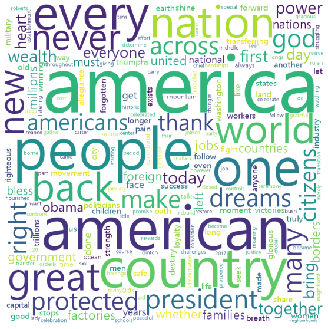

```python
# 영어 워드크라우드
count_eng = Counter(stopped_tokens2)
wordcloud_eng = wordcloud.generate_from_frequencies(count_eng)
fig_eng = plt.figure(figsize = (10, 10))
plt.axis('off')
plt.imshow(wordcloud)
```